# Статистический анализ данных (задание 3).

Теперь попробуем возвращать в модель удалённые признаки, применяя критерий отношения правдоподобия и вычисляя $\Delta\hat{\beta}\%$:

```
##  [1] 37.479014 15.340440 52.729014  4.077412  5.201257 39.807468 12.944540
##  [8]  7.789616 13.394771 14.182305 21.186417  8.967463  7.479776 20.526143
## [15] 20.003867
```

```
## [1] "V3"  "V8"  "V17"
```

Вернем 3, 8, 17 признаки – это признаки, добавление которых значимо влияет на модель.

```
##
## Call:
## glm(formula = as.formula(f), family = binomial(), data = data)
##
## Deviance Residuals:
##     Min       1Q   Median       3Q      Max
## -2.3986  -0.4227  -0.0654   0.3745   3.4434
##
## Coefficients:
##              Estimate Std. Error z value Pr(>|z|)
## (Intercept)  65.83746   25.36179   2.596 0.009434 **
## V1           -3.35169    1.06552  -3.146 0.001658 **
## V4            1.13674    0.80799   1.407 0.159461
## V6           -2.09534    0.48601  -4.311 1.62e-05 ***
## V7           -0.72687    0.14084  -5.161 2.46e-07 ***
## V10           0.36852    0.14162   2.602 0.009265 **
## V12           0.45585    0.19343   2.357 0.018442 *
## V13          -2.79112    1.47376  -1.894 0.058242 .
## V14           0.49774    0.27767   1.793 0.073036 .
## V15           3.24692    0.90398   3.592 0.000328 ***
## V18         -50.93105   20.89856  -2.437 0.014807 *
## V19         -15.70884  577.83292  -0.027 0.978312
## V20          -2.32073    0.82799  -2.803 0.005066 **
## V24           5.44951    1.81794   2.998 0.002721 **
## V29          -2.23785    1.59611  -1.402 0.160895
## V30           0.02861    0.01903   1.503 0.132731
## V31           0.29423    0.13747   2.140 0.032332 *
## V32          -1.15733    0.32556  -3.555 0.000378 ***
## V34          -0.42326    0.09629  -4.396 1.10e-05 ***
## V36           2.53926    1.05116   2.416 0.015706 *
## V37           2.25699    0.62317   3.622 0.000293 ***
## V39          -3.16204    1.13763  -2.780 0.005444 **
## V40           1.24723    0.41565   3.001 0.002694 **
## V3           -0.64342    0.37338  -1.723 0.084849 .
## V8            0.03919    0.04696   0.835 0.403931
## V17          -6.45010   11.35269  -0.568 0.569929
## ---
## Signif. codes:  0 '***' 0.001 '**' 0.01 '*' 0.05 '.' 0.1 ' ' 1
##
## (Dispersion parameter for binomial family taken to be 1)
##
##     Null deviance: 1349.0  on 1054  degrees of freedom
## Residual deviance:  621.7  on 1029  degrees of freedom
## AIC: 673.7
##
## Number of Fisher Scoring iterations: 15
```

```
## Likelihood ratio test
##
## Model 1: class ~ V1 + V3 + V4 + V5 + V6 + V7 + V8 + V9 + V10 + V11 + V12 +
##     V13 + V14 + V15 + V17 + V18 + V19 + V20 + V21 + V22 + V23 +
##     V24 + V25 + V26 + V27 + V29 + V30 + V31 + V32 + V33 + V34 +
##     V36 + V37 + V38 + V39 + V40 + V41
## Model 2: class ~ V1 + V4 + V6 + V7 + V10 + V12 + V13 + V14 + V15 + V18 +
##     V19 + V20 + V24 + V29 + V30 + V31 + V32 + V34 + V36 + V37 +
##     V39 + V40 + V3 + V8 + V17
##   #Df  LogLik  Df  Chisq Pr(>Chisq)
## 1  38 -307.21
## 2  26 -310.85 -12 7.2917     0.8378
```

Построим модель с признаками, значимыми на уровне не менее 0.15 в предыдущей модели:

```
## Likelihood ratio test
##
## Model 1: class ~ V1 + V4 + V6 + V7 + V10 + V12 + V13 + V14 + V15 + V18 +
##     V19 + V20 + V24 + V29 + V30 + V31 + V32 + V34 + V36 + V37 +
##     V39 + V40 + V3 + V8 + V17
## Model 2: class ~ V1 + V6 + V7 + V10 + V12 + V13 + V14 + V15 + V18 + V20 +
##     V24 + V30 + V31 + V32 + V34 + V36 + V37 + V39 + V40 + V3
##   #Df  LogLik Df  Chisq Pr(>Chisq)
## 1  26 -310.85
## 2  21 -314.96 -5 8.2088     0.1451
```

Эта модель не хуже предыдущей, её и оставим, проверим линейность логита по непрерывным признакам. Сглаженные диаграммы рассеяния:

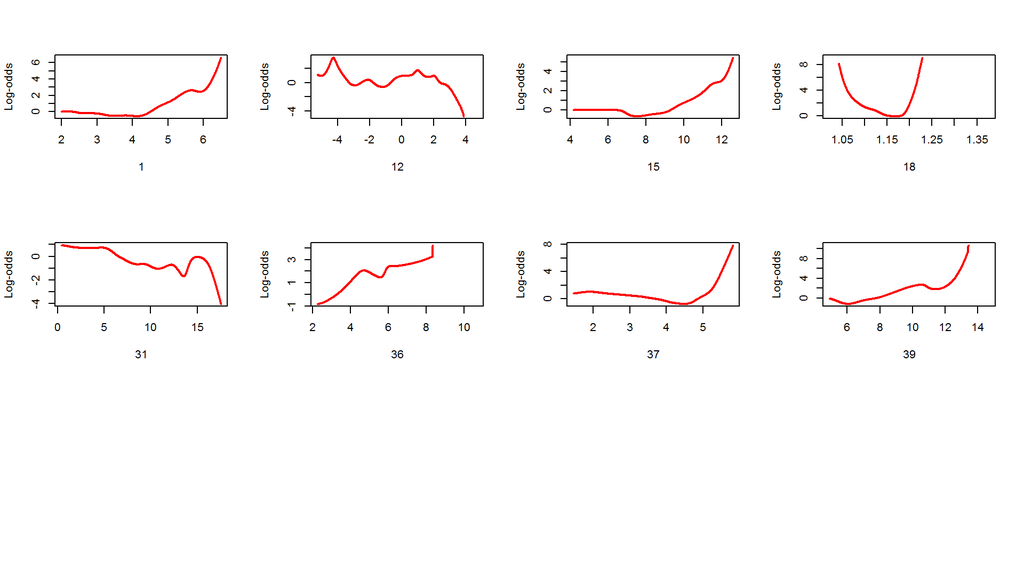

На линейные не похожи, попробуем подобрать дробные полиномы:

```
## Call:
## mfp(formula = class ~ fp(V1) + V6 + V7 + V10 + fp(V12) + fp(V13) +
##     fp(V14) + fp(V15) + fp(V18) + V20 + V24 + V30 + fp(V31) +
##     V32 + V34 + fp(V36) + fp(V37) + fp(V39) + V40 + V3, data = data,
##     family = binomial)
##
##
## Deviance table:
##           Resid. Dev
## Null model    1348.972
## Linear model  629.9124
## Final model   629.9124
##
## Fractional polynomials:
##     df.initial select alpha df.final power1 power2
## V18          4      1  0.05        1      1      .
## V7           1      1  0.05        1      1      .
## V37          4      1  0.05        1      1      .
## V6           1      1  0.05        1      1      .
## V34          1      1  0.05        1      1      .
## V32          1      1  0.05        1      1      .
## V15          4      1  0.05        1      1      .
## V20          1      1  0.05        1      1      .
## V40          1      1  0.05        1      1      .
## V3           1      1  0.05        1      1      .
## V1           4      1  0.05        1      1      .
## V24          1      1  0.05        1      1      .
## V39          4      1  0.05        1      1      .
## V10          1      1  0.05        1      1      .
## V12          4      1  0.05        1      1      .
## V31          4      1  0.05        1      1      .
## V13          4      1  0.05        1      1      .
## V14          4      1  0.05        1      1      .
## V36          4      1  0.05        1      1      .
## V30          1      1  0.05        1      1      .
##
##
## Transformations of covariates:
##                 formula
## V1         I((V1/10)^1)
```

[output cut: 21 more lines]

```
## Non-positive values in some of the covariates. No re-scaling was performed.
##
## Coefficients:
## Intercept      V18.1       V7.1      V37.1       V6.1      V34.1
##   73.0272   -64.2185    -0.7302     2.0547    -2.0987    -0.4259
##     V32.1      V15.1      V20.1      V40.1       V3.1       V1.1
##   -1.1736    31.4202    -2.3613     1.2304    -0.8910   -31.8511
##     V24.1      V39.1      V10.1      V12.1      V31.1      V13.1
##    3.6347   -30.1703     0.3000     4.4403     0.2711   -25.1347
##     V14.1      V36.1      V30.1
##    0.5060    23.5114     0.0265
##
## Degrees of Freedom: 1054 Total (i.e. Null);  1034 Residual
## Null Deviance:       1349
## Residual Deviance: 629.9     AIC: 671.9
```

Лучше линейной модели не нашли. Рассмотрим теперь все модели, в которые добавлено одно межфакторное взаимодействие:

```
## Single term additions
##
## Model:
## class ~ V1 + V6 + V7 + V10 + V12 + V13 + V14 + V15 + V18 + V20 +
##     V24 + V30 + V31 + V32 + V34 + V36 + V37 + V39 + V40 + V3
##         Df Deviance    AIC     LRT  Pr(>Chi)
## <none>       629.91 671.91
## V1:V6    1   615.44 659.44 14.4747 0.0001421 ***
## V1:V7    1   626.90 670.90  3.0147 0.0825149 .
## V1:V10   1   629.88 673.88  0.0334 0.8550705
## V1:V12   1   627.09 671.09  2.8233 0.0929041 .
## V1:V13   1   629.90 673.90  0.0076 0.9306167
## V1:V14   1   625.19 669.19  4.7203 0.0298081 *
## V1:V15   1   628.82 672.82  1.0931 0.2957905
## V1:V18   1   629.67 673.67  0.2467 0.6193782
## V1:V20   1   629.57 673.57  0.3464 0.5561575
## V1:V24   1   627.46 671.46  2.4485 0.1176371
## V1:V30   1   629.60 673.60  0.3131 0.5757712
## V1:V31   1   628.92 672.92  0.9915 0.3193870
## V1:V32   1   612.92 656.92 16.9911 3.755e-05 ***
## V1:V34   1   629.78 673.78  0.1357 0.7126428
## V1:V36   1   629.91 673.91  0.0001 0.9927409
## V1:V37   1   629.90 673.90  0.0141 0.9055026
## V1:V39   1   629.80 673.80  0.1169 0.7324588
## V1:V40   1   627.29 671.29  2.6256 0.1051503
## V1:V3    1   629.74 673.74  0.1745 0.6761052
## V6:V7    1   628.20 672.20  1.7095 0.1910495
## V6:V10   1   621.09 665.09  8.8240 0.0029730 **
## V6:V12   1   626.55 670.55  3.3630 0.0666781 .
## V6:V13   1   629.69 673.69  0.2228 0.6369073
## V6:V14   1   623.09 667.09  6.8214 0.0090069 **
## V6:V15   1   622.19 666.19  7.7247 0.0054471 **
## V6:V18   1   621.92 665.92  7.9916 0.0046994 **
## V6:V20   1   629.91 673.91  0.0001 0.9908828
## V6:V24   1   629.70 673.70  0.2129 0.6444995
## V6:V30   1   629.55 673.55  0.3584 0.5494020
## V6:V31   1   627.63 671.63  2.2780 0.1312209
## V6:V32   1   619.65 663.65 10.2584 0.0013606 **
## V6:V34   1   628.94 672.94  0.9696 0.3247748
## V6:V36   1   629.24 673.24  0.6706 0.4128361
```

[output cut: 144 more lines]

```
## V34:V39  1   629.86 673.86  0.0527 0.8184973
## V34:V40  1   628.07 672.07  1.8392 0.1750412
## V34:V3   1   628.92 672.92  0.9882 0.3201798
## V36:V37  1   629.91 673.91  0.0002 0.9880781
## V36:V39  1   629.90 673.90  0.0086 0.9261876
## V36:V40  1   626.27 670.27  3.6456 0.0562172 .
## V36:V3   1   629.63 673.63  0.2872 0.5920325
## V37:V39  1   629.66 673.66  0.2496 0.6173289
## V37:V40  1   629.19 673.19  0.7271 0.3938365
## V37:V3   1   628.01 672.01  1.9016 0.1678940
## V39:V40  1   624.92 668.92  4.9900 0.0254943 *
## V39:V3   1   629.72 673.72  0.1955 0.6583807
## V40:V3   1   629.76 673.76  0.1546 0.6941823
## ---
## Signif. codes:  0 '***' 0.001 '**' 0.01 '*' 0.05 '.' 0.1 ' ' 1
```

Добавим все межфакторные взаимодействия, значимые на уровне 0.001:

```
##
## Call:
## glm(formula = as.formula(f), family = binomial(), data = data)
##
## Deviance Residuals:
##     Min       1Q   Median       3Q      Max
## -2.4006  -0.4064  -0.0669   0.3226   3.2168
##
## Coefficients:
##              Estimate Std. Error z value Pr(>|z|)
## (Intercept)  79.43104   12.38000   6.416 1.40e-10 ***
## V1           -3.01473    1.07235  -2.811  0.00493 **
## V6          -21.85054   10.25561  -2.131  0.03312 *
## V7           -0.79720    0.14271  -5.586 2.32e-08 ***
## V10           0.35351    0.13282   2.662  0.00778 **
## V12           0.47312    0.20954   2.258  0.02396 *
## V13          -2.94648    1.48362  -1.986  0.04703 *
## V14           0.50444    0.27107   1.861  0.06276 .
## V15           3.34860    0.84953   3.942 8.09e-05 ***
## V18         -68.07256    9.74645  -6.984 2.86e-12 ***
## V20          -2.43790    0.81727  -2.983  0.00285 **
## V24           5.09720    2.06624   2.467  0.01363 *
## V30           0.02448    0.01958   1.250  0.21123
## V31           0.30767    0.13804   2.229  0.02582 *
## V32         -10.08589    5.19414  -1.942  0.05216 .
## V34          -0.46413    0.09982  -4.650 3.32e-06 ***
## V36           1.99084    1.48982   1.336  0.18145
## V37           2.27032    0.40277   5.637 1.73e-08 ***
## V39          -3.04678    1.30524  -2.334  0.01958 *
## V40           1.21003    0.41712   2.901  0.00372 **
## V3           -0.82345    0.31086  -2.649  0.00807 **
## V1:V6         4.41716    1.75251   2.520  0.01172 *
## V1:V32        1.68139    1.00425   1.674  0.09407 .
## V6:V37       -1.70779    0.83948  -2.034  0.04192 *
## ---
## Signif. codes:  0 '***' 0.001 '**' 0.01 '*' 0.05 '.' 0.1 ' ' 1
##
## (Dispersion parameter for binomial family taken to be 1)
##
##     Null deviance: 1348.97  on 1054  degrees of freedom
## Residual deviance:  596.26  on 1031  degrees of freedom
## AIC: 644.26
##
## Number of Fisher Scoring iterations: 10
```